# Movies revenue prediction

#### A Regression, K-NN, SVM application.

by Dave Emmanuel Q. Magno and Aries Valeriano

## Executive Summary

The main goal of this project is to build a prediction model which takes features such as budget, company, country, director, genre, rating, released, runtime, votes, star, writer, year as predictors to predict the gross/ revenue of a movie.

To achieve this goal, data processing up to predictive modelling were performed. Moreover, for reproducibility, syntax are shown with corresponding comments for better understanding about its used.

In the data processing, several steps were performed due to the datasets having categorical variables with too many levels, as well as variable that have missing values. For categorical variables, one hat encoding method were performed. As for the missing value, after visualising its distribution, it was found out that there are too many outliers and as result median imputation was performed over mean imputation since it is more robust to outliers.

In predictive modelling, to find the model that could produced the highest accuracy, different types of regression model such as; multiple linear regression, ridge, lasso, and elastic net were performed. In addition, support vector machine, and k-nearest neighbor models were also performed to compare there predictive accuracy to regression models.

## Jupyter Display Settings

```python
%%javascript
IPython.OutputArea.prototype._should_scroll = function(lines) {
    return false;
}
```

```python
from IPython.core.display import HTML
HTML("""
<style>
.output_png {
    display: table-cell;
    text-align: center;
    vertical-align: middle;
}
</style>
""")
```

## Prerequisites

Below are packages that are necessary to perform the task.

```python
import warnings
warnings.filterwarnings('ignore')
import copy
from typing import Tuple, List

# Data manipulations
from dfply import *
import numpy as np
import pandas as pd
import pickle

# Visualization
import matplotlib.pyplot as plt
plt.rc('axes', labelsize=14)
plt.rc('xtick', labelsize=12)
plt.rc('ytick', labelsize=12)
import seaborn as sns

# Preprocessing
from sklearn.impute import SimpleImputer
from sklearn.preprocessing import OneHotEncoder, LabelEncoder
from sklearn.pipeline import Pipeline
from sklearn.preprocessing import MinMaxScaler
from sklearn.model_selection import train_test_split

# Modeling
from sklearn.linear_model import (LinearRegression,
                                  Ridge,
                                  Lasso,
                                  ElasticNet)
from sklearn.svm import SVR
from sklearn.model_selection import (cross_val_score,
                                     GridSearchCV,
                                     RepeatedKFold)

from sklearn.neighbors import (KNeighborsClassifier,
                               KNeighborsRegressor)
from sklearn.metrics import (mean_absolute_error,
                             mean_squared_error,
                             r2_score)


import statsmodels.api as sm
import scipy.stats as stats
import datetime                        # For date time extraction

%matplotlib inline
sns.set()
plt.style.use('seaborn-whitegrid')
```

## Tools

Below are defined functions for later use.

```python
def get_unique(df: pd.DataFrame) -> dict:
    """Get distinct values or categories in categorical
    columns."""
    return {col_name: len(set(df[col_name]))
            for col_name in df.columns}

def lump_categories(df: pd.DataFrame):
    """Lumps categories who has lesser counts
    than the threshold to 'Others'."""

    def set_threshold(df: pd.DataFrame,
                      percentage: float=0.015) -> float:
        """Sets threshold to be a percentage of the size
        of dataset."""
        return df.shape[0] * percentage

    return df.apply(
        lambda x: x.mask(
            x.map(
                x.value_counts()) < set_threshold(df),
                         'Others')
        if x.name in list(df.columns) else x)

def replace_by_threshold(series: pd.Series,
                         threshold: int=9) -> pd.Series:
    """Replaces director, star, and writer values
    by 1 if > 9 and 0 otherwise."""

    def map_frequency(series: pd.Series) -> dict:
        """Get frequency for each category and maps
        each labels to its frequency."""
        return series.value_counts().to_dict()

    def replace_by_frequency(series: pd.Series,
                             mapping: dict) -> pd.Series:
        """Replaces the labels by its frequency."""
        return series.map(mapping)

    mapping = map_frequency(series)
    new_series = replace_by_frequency(series,
                                      mapping)

    return np.where(new_series > threshold, 1, 0)

def extract_day(data: pd.Series) -> pd.Series:
    """Given the released date, extract
    only the day."""
    return data.dt.day_name()

def extract_month(data: pd.Series) -> pd.Series:
    """Given the released date, extract
    only the month."""
    return data.dt.month_name()

class pipe:
    def __init__(self, value, func=None):
        self.value = value
        self.func = func
    def __getitem__(self, func):
        return pipe(self.value, func)
    def __call__(self, *args, **kwargs):
        return pipe(self.func(self.value, *args, **kwargs))
    def __repr__(self):
        return 'pipe(%s, %s)' % (self.value, self.func)

def encode_label(df: pd.DataFrame) -> pd.DataFrame:
    """Encode categories as labels, same with
    LabelEncoder() by scikit-learn."""
    for col in df.columns:
        df[col] = df[col].astype('category')
        df[col] = df[col].cat.codes
    return df

def get_cv_scores(model):
    """Function to get cross validation scores."""
    scores = cross_val_score(model,
                             X_train,
                             y_train,
                             cv=5,
                             scoring='r2')
    print(f"CV Mean: {round(np.mean(scores)*100, 2)}")
    print(f"STD: {round(np.std(scores), 2)}")

def tune_model(X: pd.DataFrame,
               y: pd.DataFrame,
               estimator,
               scoring,
               param_grid: dict,
               cv: int=None):
    cv = RepeatedKFold(n_splits=5, n_repeats=5, random_state=7)
    model = GridSearchCV(estimator=estimator,
                         param_grid=param_grid,
                         scoring=scoring,
                         cv=cv,
                         refit=True,
                         verbose=1,
                         n_jobs=-1)
    model_result = model.fit(X,y)

    print()
    print(f"Best score: {round(model_result.best_score_ * 100, 2)}")
    print(f"Best params: {model_result.best_params_}")
    print()

    return model_result

# Testing model with tuned params
def test_model(X: pd.DataFrame,
               y: pd.DataFrame,
               tuned_model) -> float:
    model = tuned_model.best_estimator_
    predictions = model.predict(X)
    score = accuracy_score(y, predictions)
    return score

def final_comparison(models,
                     X_test: pd.DataFrame,
                     y_test: pd.DataFrame):
    scores = pd.DataFrame()
    for model in models:
        predictions = model.predict(X_test)
        mae = round(mean_absolute_error(y_test, predictions), 4)
        mse = round(mean_squared_error(y_test, predictions), 4)
        r2 = round(r2_score(y_test, predictions), 4)
        errors = abs(predictions - y_test)
        mape = 100 * np.mean(errors / y_test)
        accuracy = round(100 - mape, 4)
        scores[str(model)] = [mae, mse, r2, accuracy]
    scores.index = ['Mean Absolute Error', 'Mean Squared Error', 'R^2', 'Accuracy']
    return scores
```

## Data Description

The data is available at https://www.kaggle.com/danielgrijalvas/movies. This is a three decades worth of movie data (1986-2016), scraped from IMDb using Python. The dataset has the following content:

There are 6820 movies in the dataset (220 movies per year, 1986-2016). Each movie has the following attributes:

- budget: the budget of a movie. Some movies don’t have this, so it appears as 0
- company: the production company
- country: country of origin
- director: the director
- genre: main genre of the movie.
- gross: revenue of the movie
- name: name of the movie
- rating: rating of the movie (R, PG, etc.)
- released: release date (YYYY-MM-DD)
- runtime: duration of the movie
- score: IMDb user rating
- votes: number of user votes
- star: main actor/actress
- writer: writer of the movie
- year: year of release

The task at hand, is to predict the revenue/gross using the rest of the features.

These dataset will be split into training set which contains (4774) samples and testing set which contains (2046) samples. Training set is used for building a model and testing set will be used for assessing the accuracy of the model built from training set.

#### Movies Industry Dataset

```python
df = pd.read_csv("movies.csv", encoding='ISO-8859-1')
```

#### Copy data

To avoid referencing from the original raw data, the 'deep' parameter is set to True.

```python
df_copy = df.copy(deep=True)
```

#### Separate features and target

Create dataframes for descriptive features and target feature exclusively.

```python
X_df = (df_copy >>
          drop(X.name, X.score) >>
          select(X.loc[:, X.columns != 'gross']))
y_df = df_copy['gross']
```

```python
print(f"X_df shape: {X_df.shape}")
print(f"y_df shape: {y_df.shape}")
```

```
X_df shape: (6820, 12)
y_df shape: (6820,)
```

## Data Exploration and Preprocessing

In here, data exploration and preprocessing of the whole datasets are performed. Information about datasets are further explored. Moreover, one hat encoding was performed to transformed categorical variables with too many levels. As for categorical variables such as director, star, and writer since its values are quite unique, it was transformed into binary data in which we set a threshold where if a certain value occured above threshold, it is '1' otherwise '0'. Some combination of levels of feature rating that seem to have a similar implication also was performed. Furthermore, the presence of missing values were investigated. Lastly, extracting data from feature released was also performed.

### Descriptive features information

```python
X_df.info()
```

```
<class 'pandas.core.frame.DataFrame'>
RangeIndex: 6820 entries, 0 to 6819
Data columns (total 12 columns):
 #   Column    Non-Null Count  Dtype
---  ------    --------------  -----
 0   budget    6820 non-null   float64
 1   company   6820 non-null   object
 2   country   6820 non-null   object
 3   director  6820 non-null   object
 4   genre     6820 non-null   object
 5   rating    6820 non-null   object
 6   released  6820 non-null   object
 7   runtime   6820 non-null   int64
 8   star      6820 non-null   object
 9   votes     6820 non-null   int64
 10  writer    6820 non-null   object
 11  year      6820 non-null   int64
dtypes: float64(1), int64(3), object(8)
memory usage: 639.5+ KB
```

### Preprocess categorical features

In here, lumping levels, one hat encoding, extracting data were performed.

#### Select categorical features from dataframe

```python
cat_feats = (X_df >>
              select(X.select_dtypes('object')))
```

```python
X_df[cat_feats.columns].info()
```

```
<class 'pandas.core.frame.DataFrame'>
RangeIndex: 6820 entries, 0 to 6819
Data columns (total 8 columns):
 #   Column    Non-Null Count  Dtype
---  ------    --------------  -----
 0   company   6820 non-null   object
 1   country   6820 non-null   object
 2   director  6820 non-null   object
 3   genre     6820 non-null   object
 4   rating    6820 non-null   object
 5   released  6820 non-null   object
 6   star      6820 non-null   object
 7   writer    6820 non-null   object
dtypes: object(8)
memory usage: 426.4+ KB
```

#### Checking for missing values

Replace 0 in budget feature with NA to treat it as missing values, then check the presence of missing values to verify.

```python
X_df = X_df.replace(0, np.nan)
X_df.isnull().sum()
```

```
budget      2182
company        0
country        0
director       0
genre          0
rating         0
released       0
runtime        0
star           0
votes          0
writer         0
year           0
dtype: int64
```

#### Get distinct values or categories in categorical columns

```python
get_unique(X_df[cat_feats.columns])
```

```
{'company': 2179,
 'country': 57,
 'director': 2759,
 'genre': 17,
 'rating': 13,
 'released': 2403,
 'star': 2504,
 'writer': 4199}
```

#### Get distinct frequency per category of 'rating'

```python
X_df['rating'].value_counts()
```

```
R                3392
PG-13            1995
PG                951
NOT RATED         174
G                 147
UNRATED            71
Not specified      63
NC-17              22
TV-MA               1
TV-PG               1
TV-14               1
B                   1
B15                 1
Name: rating, dtype: int64
```

Above shows the frequency of each category in variable rating. Notice that UNRATED and NOT RATED are separate when in fact both have similar implication. Thus, these levels should be merge.

#### Combining 'NOT RATED' and 'UNRATED' into 'UNRATED'

```python
X_df['rating'] = X_df['rating'].replace({'NOT RATED': 'UNRATED'})
```

```python
X_df['rating'].value_counts()
```

```
R                3392
PG-13            1995
PG                951
UNRATED           245
G                 147
Not specified      63
NC-17              22
TV-MA               1
TV-PG               1
TV-14               1
B                   1
B15                 1
Name: rating, dtype: int64
```

#### Preprocess 'director', 'star', 'writer'

As per suggestion, since features such as director, star, and writer are quite unique, then it would be appropriate to categorize it by number of occurence. 1 (active) if it occurs 10 or more times otherwise, 0 (non-active).

```python
activity = ['director', 'star', 'writer']
```

```python
X_df[activity] = X_df[activity].apply(replace_by_threshold)
```

```python
X_df.head()
```

|  | budget | company | country | director | genre | rating | released | runtime | star | votes | writer | year |
| --- | --- | --- | --- | --- | --- | --- | --- | --- | --- | --- | --- | --- |
| 0 | 8000000.0 | Columbia Pictures Corporation | USA | 1 | Adventure | R | 1986-08-22 | 89 | 0 | 299174 | 1 | 1986 |
| 1 | 6000000.0 | Paramount Pictures | USA | 0 | Comedy | PG-13 | 1986-06-11 | 103 | 1 | 264740 | 1 | 1986 |
| 2 | 15000000.0 | Paramount Pictures | USA | 1 | Action | PG | 1986-05-16 | 110 | 1 | 236909 | 0 | 1986 |
| 3 | 18500000.0 | Twentieth Century Fox Film Corporation | USA | 0 | Action | R | 1986-07-18 | 137 | 1 | 540152 | 0 | 1986 |
| 4 | 9000000.0 | Walt Disney Pictures | USA | 0 | Adventure | PG | 1986-08-01 | 90 | 0 | 36636 | 0 | 1986 |

#### Preprocessing 'release'

Extract the day of week and month of a year from released variable.

```python
X_df['released'] = pd.to_datetime(X_df['released'], errors='coerce')
```

```python
X_df['released']
```

```
0      1986-08-22
1      1986-06-11
2      1986-05-16
3      1986-07-18
4      1986-08-01
          ...
6815   2016-07-22
6816   2016-05-06
6817   2016-07-25
6818   2016-12-02
6819   2017-07-28
Name: released, Length: 6820, dtype: datetime64[ns]
```

#### Feature engineering of 'release'

Extract day and month from feature 'release'.

```python
X_df = (X_df >>
    mutate(dayReleased = extract_day(X.released)) >>
    mutate(monthReleased = extract_month(X.released)) >>
    drop(X.released))
```

```python
X_df.head()
```

|  | budget | company | country | director | genre | rating | runtime | star | votes | writer | year | dayReleased | monthReleased |
| --- | --- | --- | --- | --- | --- | --- | --- | --- | --- | --- | --- | --- | --- |
| 0 | 8000000.0 | Columbia Pictures Corporation | USA | 1 | Adventure | R | 89 | 0 | 299174 | 1 | 1986 | Friday | August |
| 1 | 6000000.0 | Paramount Pictures | USA | 0 | Comedy | PG-13 | 103 | 1 | 264740 | 1 | 1986 | Wednesday | June |
| 2 | 15000000.0 | Paramount Pictures | USA | 1 | Action | PG | 110 | 1 | 236909 | 0 | 1986 | Friday | May |
| 3 | 18500000.0 | Twentieth Century Fox Film Corporation | USA | 0 | Action | R | 137 | 1 | 540152 | 0 | 1986 | Friday | July |
| 4 | 9000000.0 | Walt Disney Pictures | USA | 0 | Adventure | PG | 90 | 0 | 36636 | 0 | 1986 | Friday | August |

#### Lump categories who has lesser counts than the threshold to 'Others'

In here, lumping levels of categorical variables with too many levels was performed.

```python
to_lump = (X_df >>
            select(X.company, X.country, X.genre, X.rating))
```

```python
X_df[to_lump.columns]
```

|  | company | country | genre | rating |
| --- | --- | --- | --- | --- |
| 0 | Columbia Pictures Corporation | USA | Adventure | R |
| 1 | Paramount Pictures | USA | Comedy | PG-13 |
| 2 | Paramount Pictures | USA | Action | PG |
| 3 | Twentieth Century Fox Film Corporation | USA | Action | R |
| 4 | Walt Disney Pictures | USA | Adventure | PG |
| ... | ... | ... | ... | ... |
| 6815 | Fox Searchlight Pictures | UK | Comedy | R |
| 6816 | Siempre Viva Productions | USA | Drama | PG-13 |
| 6817 | Warner Bros. Animation | USA | Animation | R |
| 6818 | Borderline Presents | USA | Drama | R |
| 6819 | Les Productions du Trésor | France | Drama | R |

6820 rows × 4 columns

```python
X_df[to_lump.columns] = lump_categories(to_lump)
```

```python
X_df.head()
```

|  | budget | company | country | director | genre | rating | runtime | star | votes | writer | year | dayReleased | monthReleased |
| --- | --- | --- | --- | --- | --- | --- | --- | --- | --- | --- | --- | --- | --- |
| 0 | 8000000.0 | Columbia Pictures Corporation | USA | 1 | Adventure | R | 89 | 0 | 299174 | 1 | 1986 | Friday | August |
| 1 | 6000000.0 | Paramount Pictures | USA | 0 | Comedy | PG-13 | 103 | 1 | 264740 | 1 | 1986 | Wednesday | June |
| 2 | 15000000.0 | Paramount Pictures | USA | 1 | Action | PG | 110 | 1 | 236909 | 0 | 1986 | Friday | May |
| 3 | 18500000.0 | Twentieth Century Fox Film Corporation | USA | 0 | Action | R | 137 | 1 | 540152 | 0 | 1986 | Friday | July |
| 4 | 9000000.0 | Others | USA | 0 | Adventure | PG | 90 | 0 | 36636 | 0 | 1986 | Friday | August |

#### LabelEncoding of 'dayReleased' and 'monthReleased'

```python
to_label = ['dayReleased', 'monthReleased']
```

```python
X_df[to_label] = encode_label(X_df[to_label])
```

```python
X_df.head()
```

|  | budget | company | country | director | genre | rating | runtime | star | votes | writer | year | dayReleased | monthReleased |
| --- | --- | --- | --- | --- | --- | --- | --- | --- | --- | --- | --- | --- | --- |
| 0 | 8000000.0 | Columbia Pictures Corporation | USA | 1 | Adventure | R | 89 | 0 | 299174 | 1 | 1986 | 0 | 1 |
| 1 | 6000000.0 | Paramount Pictures | USA | 0 | Comedy | PG-13 | 103 | 1 | 264740 | 1 | 1986 | 6 | 6 |
| 2 | 15000000.0 | Paramount Pictures | USA | 1 | Action | PG | 110 | 1 | 236909 | 0 | 1986 | 0 | 8 |
| 3 | 18500000.0 | Twentieth Century Fox Film Corporation | USA | 0 | Action | R | 137 | 1 | 540152 | 0 | 1986 | 0 | 5 |
| 4 | 9000000.0 | Others | USA | 0 | Adventure | PG | 90 | 0 | 36636 | 0 | 1986 | 0 | 1 |

#### One-Hot Encoding of some categorical features

In here, dummy variables for categorical feature levels were created.

#### Only include 'company', 'country', 'genre', and 'rating' in one-hot encoding

```python
X_df.columns[:-3]
```

```
Index(['budget', 'company', 'country', 'director', 'genre', 'rating',
       'runtime', 'star', 'votes', 'writer'],
      dtype='object')
```

```python
to_dummy = ['company', 'country', 'genre', 'rating']
```

```python
X_no_dummies = X_df.drop(to_dummy, axis=1)
```

```python
X_dummies = pd.get_dummies(data=X_df[to_dummy])
```

#### Merge all categorical features (with unprocessed numerical)

```python
X_df = pd.concat([X_no_dummies, X_dummies], axis=1)
```

```python
X_df
```

|  | budget | director | runtime | star | votes | writer | year | dayReleased | monthReleased | company_Columbia Pictures | ... | genre_Crime | genre_Drama | genre_Horror | genre_Others | rating_G | rating_Others | rating_PG | rating_PG-13 | rating_R | rating_UNRATED |
| --- | --- | --- | --- | --- | --- | --- | --- | --- | --- | --- | --- | --- | --- | --- | --- | --- | --- | --- | --- | --- | --- |
| 0 | 8000000.0 | 1 | 89 | 0 | 299174 | 1 | 1986 | 0 | 1 | 0 | ... | 0 | 0 | 0 | 0 | 0 | 0 | 0 | 0 | 1 | 0 |
| 1 | 6000000.0 | 0 | 103 | 1 | 264740 | 1 | 1986 | 6 | 6 | 0 | ... | 0 | 0 | 0 | 0 | 0 | 0 | 0 | 1 | 0 | 0 |
| 2 | 15000000.0 | 1 | 110 | 1 | 236909 | 0 | 1986 | 0 | 8 | 0 | ... | 0 | 0 | 0 | 0 | 0 | 0 | 1 | 0 | 0 | 0 |
| 3 | 18500000.0 | 0 | 137 | 1 | 540152 | 0 | 1986 | 0 | 5 | 0 | ... | 0 | 0 | 0 | 0 | 0 | 0 | 0 | 0 | 1 | 0 |
| 4 | 9000000.0 | 0 | 90 | 0 | 36636 | 0 | 1986 | 0 | 1 | 0 | ... | 0 | 0 | 0 | 0 | 0 | 0 | 1 | 0 | 0 | 0 |
| ... | ... | ... | ... | ... | ... | ... | ... | ... | ... | ... | ... | ... | ... | ... | ... | ... | ... | ... | ... | ... | ... |
| 6815 | NaN | 0 | 91 | 0 | 9161 | 0 | 2016 | 0 | 5 | 0 | ... | 0 | 0 | 0 | 0 | 0 | 0 | 0 | 0 | 1 | 0 |
| 6816 | NaN | 0 | 90 | 0 | 1959 | 0 | 2016 | 0 | 8 | 0 | ... | 0 | 1 | 0 | 0 | 0 | 0 | 0 | 1 | 0 | 0 |
| 6817 | 3500000.0 | 0 | 76 | 0 | 36333 | 0 | 2016 | 1 | 5 | 0 | ... | 0 | 0 | 0 | 0 | 0 | 0 | 0 | 0 | 1 | 0 |
| 6818 | NaN | 0 | 76 | 0 | 6947 | 0 | 2016 | 0 | 2 | 0 | ... | 0 | 1 | 0 | 0 | 0 | 0 | 0 | 0 | 1 | 0 |
| 6819 | NaN | 0 | 120 | 0 | 2411 | 0 | 2016 | 0 | 5 | 0 | ... | 0 | 1 | 0 | 0 | 0 | 0 | 0 | 0 | 1 | 0 |

6820 rows × 39 columns

### Preprocess numeric features

Enumerate numerical descriptive features, then do data imputation and data normalization.

```python
numeric_names = ['budget', 'runtime', 'votes']
```

```python
X_df[numeric_names] = (X_df >>
                        select(X.budget, X.runtime, X.votes))
```

#### Check missing values

```python
X_df.isnull().sum()
```

```
budget                                            2182
director                                             0
runtime                                              0
star                                                 0
votes                                                0
writer                                               0
year                                                 0
dayReleased                                          0
monthReleased                                        0
company_Columbia Pictures                            0
company_Columbia Pictures Corporation                0
company_New Line Cinema                              0
company_Others                                       0
company_Paramount Pictures                           0
company_Touchstone Pictures                          0
company_Twentieth Century Fox Film Corporation       0
company_Universal Pictures                           0
company_Warner Bros.                                 0
country_Canada                                       0
country_France                                       0
country_Germany                                      0
country_Others                                       0
country_UK                                           0
country_USA                                          0
genre_Action                                         0
genre_Adventure                                      0
genre_Animation                                      0
genre_Biography                                      0
genre_Comedy                                         0
genre_Crime                                          0
genre_Drama                                          0
genre_Horror                                         0
genre_Others                                         0
rating_G                                             0
rating_Others                                        0
rating_PG                                            0
rating_PG-13                                         0
rating_R                                             0
rating_UNRATED                                       0
dtype: int64
```

As shown above, the variable budget have 2182 missing values and the rest have 0. To address this, data imputation might be necessary to avoid loss of information.

```python
mean(X_df['budget'])
```

```
36145601.601768
```

#### Preprocessing budget

Previously, it was found out that variable budget have missing values. To assess which data imputation (mean, median, mode) is appropriate for this, box-plot was performed to observed the distribution of this variable.

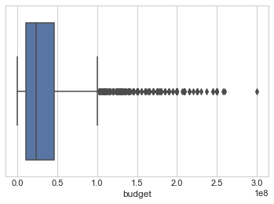

```python
sns.boxplot(X_df['budget'])
plt.show()
```

Observed that in the figure above, there are lots of points outside the boxplot. These points are outliers which can affect immensely the mean. Hence, it is either median or mode imputation is applicable for this data, since these two are more robust to outliers over the mean. However, this time median imputation will be performed since it is usually the case when mean is inappropriate to apply.

#### Fill missing values with median

Perform median imputation on variable budget.

```python
X_df = X_df.fillna(X_df.median())
```

#### Check again missing values

```python
X_df.isnull().sum()
```

```
budget                                            0
director                                          0
runtime                                           0
star                                              0
votes                                             0
writer                                            0
year                                              0
dayReleased                                       0
monthReleased                                     0
company_Columbia Pictures                         0
company_Columbia Pictures Corporation             0
company_New Line Cinema                           0
company_Others                                    0
company_Paramount Pictures                        0
company_Touchstone Pictures                       0
company_Twentieth Century Fox Film Corporation    0
company_Universal Pictures                        0
company_Warner Bros.                              0
country_Canada                                    0
country_France                                    0
country_Germany                                   0
country_Others                                    0
country_UK                                        0
country_USA                                       0
genre_Action                                      0
genre_Adventure                                   0
genre_Animation                                   0
genre_Biography                                   0
genre_Comedy                                      0
genre_Crime                                       0
genre_Drama                                       0
genre_Horror                                      0
genre_Others                                      0
rating_G                                          0
rating_Others                                     0
rating_PG                                         0
rating_PG-13                                      0
rating_R                                          0
rating_UNRATED                                    0
dtype: int64
```

Notice above that, variable budget now has 0 missing value. This means median imputation was succesful. We can now use these imputed budget variable in the succeeding process.

## Data Split

Split the data into training set and testing set for further analysis. The proportion of data split here is 70:30. This was decided to have a bigger datasets available for model building.

```python
X_train, X_test, y_train, y_test = train_test_split(X_df, y_df,
                                                    test_size=0.30,
                                                    random_state=7,
                                                    shuffle=True)
```

```python
print(f"Training set shape: {X_train.shape}")
print(f"Testing set shape: {X_test.shape}")
```

```
Training set shape: (4774, 39)
Testing set shape: (2046, 39)
```

```python
X_train.columns
```

```
Index(['budget', 'director', 'runtime', 'star', 'votes', 'writer', 'year',
       'dayReleased', 'monthReleased', 'company_Columbia Pictures',
       'company_Columbia Pictures Corporation', 'company_New Line Cinema',
       'company_Others', 'company_Paramount Pictures',
       'company_Touchstone Pictures',
       'company_Twentieth Century Fox Film Corporation',
       'company_Universal Pictures', 'company_Warner Bros.', 'country_Canada',
       'country_France', 'country_Germany', 'country_Others', 'country_UK',
       'country_USA', 'genre_Action', 'genre_Adventure', 'genre_Animation',
       'genre_Biography', 'genre_Comedy', 'genre_Crime', 'genre_Drama',
       'genre_Horror', 'genre_Others', 'rating_G', 'rating_Others',
       'rating_PG', 'rating_PG-13', 'rating_R', 'rating_UNRATED'],
      dtype='object')
```

## Data Preprocessing

Previously, we performed data processing and exploration considering the whole datasets. However, this time data preprocessing and data exploration were performed considering only the training set we got from splitting the dataset.

### Preprocess training set using MinMaxScaler

In here, all numeric features in training set were normalized to avoid unequal contribution to the model trained.

```python
X_train[numeric_names].isnull().sum()
```

```
budget     0
runtime    0
votes      0
dtype: int64
```

```python
scaler = MinMaxScaler()
scaler = scaler.fit(X_train[numeric_names])
X_train[numeric_names] = scaler.transform(X_train[numeric_names])
```

#### Save training parameters

```python
pickle.dump(scaler, open('scaler.pkl', 'wb'))
```

### Preprocess testing set using MinMaxScaler

Again, we normalize all numeric features however, this time it is for the testing set. The reason we've done this, is so the scale of the data in the training set would match the scale in the testing set during assessment of the accuracy of the predictive model built.

#### Load training parameters

```python
scaler = pickle.load(open('scaler.pkl', 'rb'))
```

```python
X_test[numeric_names] = scaler.transform(X_test[numeric_names])
```

```python
X_test.head()
```

|  | budget | director | runtime | star | votes | writer | year | dayReleased | monthReleased | company_Columbia Pictures | ... | genre_Crime | genre_Drama | genre_Horror | genre_Others | rating_G | rating_Others | rating_PG | rating_PG-13 | rating_R | rating_UNRATED |
| --- | --- | --- | --- | --- | --- | --- | --- | --- | --- | --- | --- | --- | --- | --- | --- | --- | --- | --- | --- | --- | --- |
| 3530 | 0.313320 | 1 | 0.381944 | 1 | 0.648205 | 0 | 2002 | 6 | 2 | 0 | ... | 0 | 0 | 0 | 0 | 0 | 0 | 0 | 1 | 0 | 0 |
| 6521 | 0.299986 | 0 | 0.107639 | 0 | 0.006416 | 0 | 2015 | 0 | 2 | 0 | ... | 0 | 0 | 0 | 0 | 0 | 0 | 1 | 0 | 0 | 0 |
| 4396 | 0.041647 | 0 | 0.194444 | 0 | 0.009318 | 0 | 2005 | 6 | 6 | 0 | ... | 0 | 0 | 0 | 0 | 0 | 0 | 0 | 0 | 0 | 1 |
| 2551 | 0.076648 | 0 | 0.173611 | 0 | 0.004139 | 0 | 1997 | 0 | 11 | 0 | ... | 0 | 0 | 0 | 0 | 0 | 0 | 0 | 0 | 1 | 0 |
| 5523 | 0.166650 | 0 | 0.190972 | 1 | 0.063813 | 0 | 2011 | 0 | 2 | 0 | ... | 0 | 0 | 0 | 0 | 0 | 0 | 1 | 0 | 0 | 0 |

5 rows × 39 columns

## Data Exploration

In here, data exploration of the traning set was performed. Specifically, investigating the relationship between features and descriptive statictics such as mean, count, etc. were performed.

```python
X_train_num = pd.concat([X_train[numeric_names], y_train],
                         axis=1)
```

```python
X_train_num.describe()
```

|  | budget | runtime | votes | gross |
| --- | --- | --- | --- | --- |
| count | 4774.000000 | 4774.000000 | 4774.000000 | 4.774000e+03 |
| mean | 0.105403 | 0.129983 | 0.038054 | 3.293826e+07 |
| std | 0.110827 | 0.061972 | 0.072153 | 5.725860e+07 |
| min | 0.000000 | 0.000000 | 0.000000 | 3.090000e+02 |
| 25% | 0.051648 | 0.090278 | 0.004013 | 1.495060e+06 |
| 50% | 0.076648 | 0.114583 | 0.013585 | 1.169048e+07 |
| 75% | 0.099982 | 0.159722 | 0.039031 | 3.873612e+07 |
| max | 1.000000 | 1.000000 | 1.000000 | 7.605076e+08 |

Above result, gives us idea how spread points are for every feature shown by looking at the value of std. It does seem that runtime and votes are less spread compared to budget and gross. However, when comparing budget and gross it seems that gross is a lot more spread since std of budget is too small. Recall earlier that budget was normalized together with other numeric descriptive features whereas, gross/revenue is the target feature which we haven't normalize. That probably explains the great difference between there std. As for the central tendency of the features, obviously gross has the highest average and votes has the smallest expected value. And the rest can just be interpreted as it is.

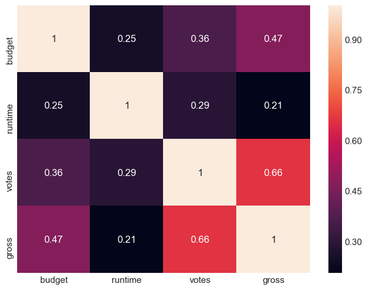

```python
fig=plt.figure(figsize=(8,6), dpi= 100)
sns.heatmap(X_train_num.corr(method='spearman'),
            annot=True)
plt.show()
```

Above figure shows the spearman correlation coefficient between each pair of numerical features including gross/revenue the target feature. Observe that gross and votes have somewhat moderate relationship having 0.66 coefficient. Whereas, gross and budget together with the pair votes and budget have little relationship having 0.47 and 0.36 coefficients respectively. These indicates, that budget and votes might fairly contribute in building the predictive model. As for feature runtime, its coefficient with gross is greater than 0, so we still dont exclude the chance that it will still contribute even a little.

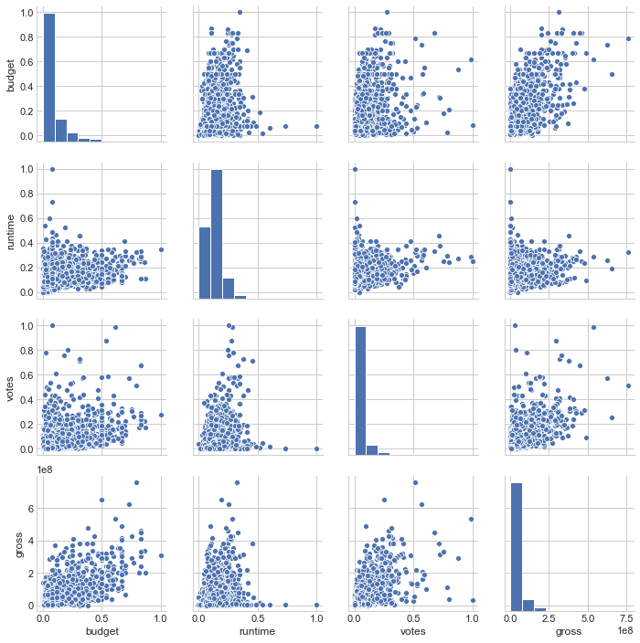

```python
sns.pairplot(X_train_num)
```

Above shows the plot between each pair of numerical feature. Notice that, gross and budget have somewhat positive linear relationship, same goes with votes and gross although there are more outliers compared to the former. As for the relationship between runtime and gross, there does seem a positive linear relationship however it seeems quite little. These actually let us visualize the result in spearman correlation coefficienct previously.

## Model Selection

In here, Multiple linear regression, Ridge Regression, Lasso Regression, Elastic Net Regression, Support Vector Machine, and K-Nearest Neighbors were performed to build a model that could give the highest predictive accuracy.

#### Hyperparameters

Hyperparameter tuning was performed here to optimize the models. Specifically, 5-fold cross validation repeated 5 times with specified set of hyperparameters.

```python
# Support Vector Machines
param_grid3 = {'kernel':('linear', 'rbf'), 'C':[1, 10]}
```

### Multiple Linear Regression

```python
model = LinearRegression()
model.fit(X_train, y_train)
get_cv_scores(model)
```

```
CV Mean: 64.89
STD: 0.06
```

As shown, the predictive accuracy we get by employing multiple linear regression is 64.89%. This imply that given the following descriptive features; 'budget', 'director', 'runtime', 'star', 'votes', 'writer', 'year', 'dayReleased', 'monthReleased', 'company_Columbia Pictures', 'company_Columbia Pictures Corporation', 'company_New Line Cinema', 'company_Others', 'company_Paramount Pictures', 'company_Touchstone Pictures', 'company_Twentieth Century Fox Film Corporation', 'company_Universal Pictures', 'company_Warner Bros.', 'country_Canada', 'country_France', 'country_Germany', 'country_Others', 'country_UK','country_USA', 'genre_Action', 'genre_Adventure', 'genre_Animation', 'genre_Biography', 'genre_Comedy', 'genre_Crime', 'genre_Drama', 'genre_Horror', 'genre_Others', 'rating_G', 'rating_Others', 'rating_PG', 'rating_PG-13', 'rating_R', 'rating_UNRATED' we can predict the gross/revenue of a movie with 64.89% accuracy.